# DSP4SH Phase 2 - SOC Stock and Indicator Analysis

Katy Dynarski

2023-11-24

# Map and overview of DSP4SH projects

Map of DSP4SH Projects:

```
## Scale on map varies by more than 10%, scale bar may be inaccurate
```

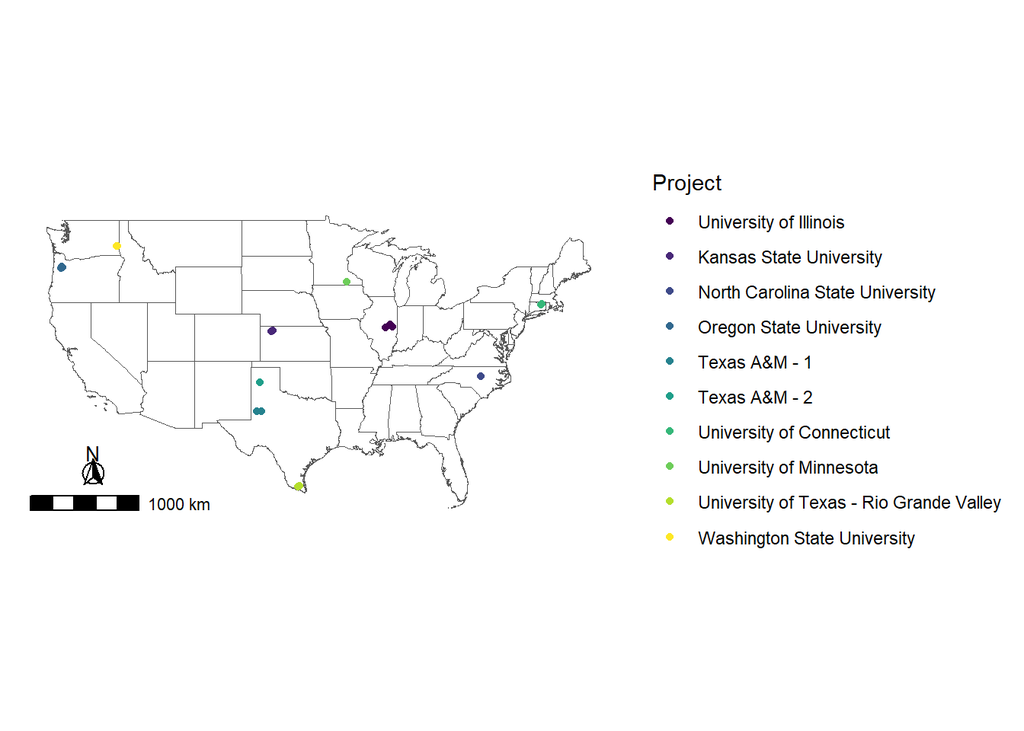

```r
# Download map of USA from NaturalEarth as basemap
usa_ne <- ne_states(country="united states of america")

# Make dataframe for adding project data annotation to map
# What I want - just one point for each project label combination, text label describing project
# Many projects have more than one type of treatment within a label - look at the data to be able to write a description that generally covers things:
project_distinct <- project %>%
  distinct(project, label, lu, till, trt, explanation)

# Write tibble of annotation for each project/label based on project_distinct
annotation <- tibble(project=c(rep("Illinois", 3),
                               rep("KansasState", 3),
                               rep("NCState", 3),
                               rep("OregonState", 3),
                               rep("TexasA&MPt-1", 3),
                               rep("TexasA&MPt-2", 3),
                               rep("UConn", 3),
                               rep("UTRGV", 2),
                               rep("UnivOfMinnesota", 3),
                               rep("WashingtonState", 3)),
                     label=c(rep(c("BAU", "Ref", "SHM"), 7), "BAU", "Ref", rep(c("BAU", "Ref", "SHM"), 2)),
                     annotation=c("BAU: Conventional and organic corn-soybean rotation",
                "Ref: Forest restored in 1990",
                "SHM: No-till corn-soybean rotation",
                "BAU: Diverse crops with conventional tillage",
                "Ref: Native rangeland",
                "SHM: No-till diverse crops and cover cropping",
                "BAU: Wheat and corn with conventional tillage",
                "Ref: Forest",
                "SHM: Hayed perennial grass",
                "BAU: Ryegrass and Christmas tree with tillage",
                "Ref: Timber forest and hazelnut orchard",
                "SHM: No-till grass and vineyard",
                "BAU: Cropping with conventional tillage",
                "Ref: Native rangeland",
                "SHM: No-till rye and mixed crops",
                "BAU: Wheat and sorghum with conventional tillage",
                "Ref: Native perennial forage",
                "SHM: No-till wheat and sorghum",
                "BAU: Corn with conventional tillage",
                "Ref: Forest",
                "SHM: No-till corn and hay",
                "BAU: Diverse crops with conventional tillage",
                "Ref: Native forest",
                "BAU: Soybean with conventional tillage",
                "Ref: Native rangeland",
                "SHM: No-till soybean",
                "BAU: Cropping with conventional tillage",
                "Ref: Perennial grassland",
                "SHM: No-till cropping"))

# Get unique soil series
project_soil <- project %>%
  distinct(project, soil) %>%
  group_by(project) %>%
  mutate(count = paste("soil",seq(n()), sep="_")) %>%
  pivot_wider(names_from=count, values_from=soil) %>%
  unite("soils", soil_1:soil_3, sep=", ", na.rm=TRUE)


# Make annotation dataframe that includes project, label, soil, and xy coords
project_annotate <- project %>%
  group_by(project, label) %>%
  mutate(avg_lat = mean(lat, na.rm=TRUE),
         avg_long = mean(long, na.rm=TRUE)) %>%
  distinct(project, label, avg_lat, avg_long) %>%
  left_join(annotation, by=c("project", "label")) %>%
  left_join(project_soil, by="project")

# Make map
ggplot(data=usa_ne) +
  geom_sf(fill=NA) +
  coord_sf(xlim=c(-125.0, -66.93457), ylim=c(24.396308, 49.384358)) + # set bounding box around CONUS
  annotation_north_arrow(location="bl", which_north="true", height=unit(.25, "in"), width=unit(.25, "in"),
                         pad_x = unit(0.4, "in"), pad_y = unit(0.25, "in"), style=north_arrow_fancy_orienteering) + # add north arrow
  annotation_scale(location = "bl") +
  geom_point(data=project_annotate, aes(x=avg_long, y=avg_lat, color=project)) +
  scale_color_viridis(discrete=TRUE,
                      name="Project", labels=c("University of Illinois", "Kansas State University", "North Carolina State University",
                                                "Oregon State University", "Texas A&M - 1", "Texas A&M - 2", "University of Connecticut",
                                                "University of Minnesota", "University of Texas - Rio Grande Valley",
                                                "Washington State University")) +
  theme_classic() +
  easy_remove_axes()
```

```r
# I had originally wanted to annotate this with project information but it's way too messy
```

It’s also nice to have an overview table of what the different projects are.

```r
project_table <- project_annotate %>%
  group_by(project) %>%
  select(project, soils, annotation) %>%
  separate_wider_delim(annotation, delim=": ", names=c("label", "description")) %>%
  ungroup()
gt(project_table)
```

| project | soils | label | description |
| --- | --- | --- | --- |
| Illinois | Drummer, Dana, Flanagan | BAU | Conventional and organic corn-soybean rotation |
| Illinois | Drummer, Dana, Flanagan | Ref | Forest restored in 1990 |
| Illinois | Drummer, Dana, Flanagan | SHM | No-till corn-soybean rotation |
| OregonState | Jory, Woodburn | Ref | Timber forest and hazelnut orchard |
| OregonState | Jory, Woodburn | SHM | No-till grass and vineyard |
| OregonState | Jory, Woodburn | BAU | Ryegrass and Christmas tree with tillage |
| UConn | Woodbridge, Canton, Montauk | SHM | No-till corn and hay |
| UConn | Woodbridge, Canton, Montauk | BAU | Corn with conventional tillage |
| UConn | Woodbridge, Canton, Montauk | Ref | Forest |
| UTRGV | Hidalgo | BAU | Diverse crops with conventional tillage |
| UTRGV | Hidalgo | Ref | Native forest |
| KansasState | Keith | SHM | No-till diverse crops and cover cropping |
| KansasState | Keith | BAU | Diverse crops with conventional tillage |
| KansasState | Keith | Ref | Native rangeland |
| NCState | Cecil | BAU | Wheat and corn with conventional tillage |
| NCState | Cecil | Ref | Forest |
| NCState | Cecil | SHM | Hayed perennial grass |
| TexasA&MPt-1 | Amarillo | Ref | Native rangeland |
| TexasA&MPt-1 | Amarillo | BAU | Cropping with conventional tillage |
| TexasA&MPt-1 | Amarillo | SHM | No-till rye and mixed crops |
| TexasA&MPt-2 | Pullman | Ref | Native perennial forage |
| TexasA&MPt-2 | Pullman | BAU | Wheat and sorghum with conventional tillage |
| TexasA&MPt-2 | Pullman | SHM | No-till wheat and sorghum |
| UnivOfMinnesota | Readlyn, Marquis, Kenyon | BAU | Soybean with conventional tillage |
| UnivOfMinnesota | Readlyn, Marquis, Kenyon | SHM | No-till soybean |
| UnivOfMinnesota | Readlyn, Marquis, Kenyon | Ref | Native rangeland |
| WashingtonState | Palouse | SHM | No-till cropping |
| WashingtonState | Palouse | Ref | Perennial grassland |
| WashingtonState | Palouse | BAU | Cropping with conventional tillage |

# Summary of SOC Stocks

## Summary table of SOC stocks across projects, soils, and treatments

Mean, standard deviation, and n for SOC stocks calculated to 30 cm and 100 cm for all soils in DSP4SH phase 2.

```r
soc_summary <- soc_pedon %>%
  group_by(soil, label) %>%
  summarize(across(soc_stock_30cm:soc_stock_100cm, mean_sd), n=n())
flextable(soc_summary)
```

| soil | label | soc_stock_30cm_mean | soc_stock_30cm_sd | soc_stock_100cm_mean | soc_stock_100cm_sd | n |
| --- | --- | --- | --- | --- | --- | --- |
| Amarillo | BAU | 9.40 | 1.61 | 25.21 | 2.97 | 9 |
| Amarillo | SHM | 13.32 | 1.72 | 30.87 | 5.72 | 18 |
| Amarillo | Ref | 11.92 | 1.77 | 38.31 | 2.01 | 3 |
| Canton | SHM | 110.34 |  |  |  | 1 |
| Cecil | BAU | 87.79 | 33.44 | 111.81 | 49.24 | 9 |
| Cecil | SHM | 72.87 | 25.62 | 92.70 | 20.25 | 9 |
| Cecil | Ref | 53.13 | 2.98 | 70.21 | 8.32 | 2 |
| Drummer | BAU | 94.15 | 12.28 | 171.93 | 22.63 | 12 |
| Drummer | SHM | 95.98 | 26.37 | 203.73 | 81.93 | 4 |
| Drummer | Ref | 119.64 | 10.55 | 197.33 | 4.03 | 3 |
| Hidalgo | BAU | 53.53 | 20.09 |  |  | 27 |
| Hidalgo | Ref | 93.15 | 36.21 |  |  | 6 |
| Jory | BAU | 136.80 | 19.34 | 185.40 | 32.87 | 9 |
| Jory | SHM | 117.55 | 33.22 | 182.82 | 48.83 | 8 |
| Jory | Ref | 150.01 | 50.93 | 234.64 | 60.35 | 9 |
| Keith | BAU | 62.34 | 11.83 | 116.29 | 20.80 | 9 |
| Keith | SHM | 46.13 | 8.22 | 89.42 | 6.17 | 6 |
| Keith | Ref | 73.76 | 15.97 | 122.75 | 21.30 | 9 |
| Kenyon | Ref | 180.78 | 49.17 | 318.21 | 41.35 | 9 |
| Marquis | SHM | 143.45 | 29.14 | 203.79 | 39.57 | 9 |
| Palouse | BAU | 67.56 | 43.70 | 125.20 | 61.97 | 9 |
| Palouse | SHM | 65.51 | 30.29 | 116.58 | 51.07 | 12 |
| Palouse | Ref | 58.56 | 9.33 | 117.19 | 44.43 | 6 |
| Pullman | BAU |  |  |  |  | 9 |
| Pullman | SHM |  |  |  |  | 9 |
| Pullman | Ref |  |  |  |  | 6 |
| Readlyn | BAU | 107.93 | 17.38 | 172.67 | 38.51 | 9 |
| Woodbridge | BAU | 69.00 |  | 107.89 |  | 1 |
| Woodbridge | SHM | 101.89 | 15.16 | 122.58 |  | 5 |
| Woodbridge | Ref | 149.68 | 29.48 | 214.68 | 18.74 | 4 |
| Woodburn | BAU | 90.42 | 37.81 | 113.88 | 41.19 | 9 |
| Woodburn | SHM | 84.96 | 10.48 | 123.53 | 17.31 | 9 |
| Woodburn | Ref | 88.87 | 21.59 | 112.20 | 26.85 | 9 |

## Boxplots and mixed linear models to show effect of treatment and soil series on SOC stocks at 30 cm and 100 cm depths

The summary table shows that some some projects didn’t have a consistent soil type across the different treatments, or just didn’t have sufficient SOC data to calculate 30 cm or 100 cm depths. Data from these soils should be excluded from further analysis. These soils are: Canton (only in SHM), Hidalgo (has 30 cm stocks, not 100 cm), Pullman (only has SOC %), Kenyon (only in Ref), Marquis (only in SHM), Readlyn (only in BAU), and Woodbridge (maybe could leave? has n of 1 for BAU but does have Ref and SHM data).

```r
# For looking at soc stocks to 100 cm -
soils_exclude100 <- c("Canton", "Hidalgo", "Pullman", "Kenyon", "Marquis", "Readlyn", "Woodbridge")
soc_pedon_filt100 <- soc_pedon %>%
  filter(!soil %in% soils_exclude100)
write_csv(soc_pedon_filt100, here("data_processed", "05_soc_pedon_100cm.csv"))

# For SOC stocks to 30 cm - can also include Hidalgo soils
soils_exclude30 <- c("Canton", "Pullman", "Kenyon", "Marquis", "Readlyn", "Woodbridge")
soc_pedon_filt30 <- soc_pedon %>%
  filter(!soil %in% soils_exclude30)
write_csv(soc_pedon_filt30, here("data_processed", "05_soc_pedon_30cm.csv"))

# And the horizon data
soc_horizon_filt <- soc_horizon_all %>%
  filter(!soil %in% soils_exclude100)
write_csv(soc_horizon_filt, here("data_processed", "05_soc_horizon_filtered.csv"))
```

Use the filtered data to run a mixed linear model of SOC stocks by soil and treatment:

```r
# Run an ANOVA just for fun
anova(aov(soc_stock_100cm ~ (soil+label)^2, data=soc_pedon_filt100))
```

```
## Analysis of Variance Table
##
## Response: soc_stock_100cm
##             Df Sum Sq Mean Sq F value Pr(>F)
## soil         6 500643   83441 62.5698 <2e-16 ***
## label        2   4282    2141  1.6054 0.2043
## soil:label  12  23567    1964  1.4727 0.1404
## Residuals  149 198700    1334
## ---
## Signif. codes:  0 '***' 0.001 '**' 0.01 '*' 0.05 '.' 0.1 ' ' 1
```

```r
# try this as a LME
# Random effects: soil
# Fixed effects: label
soc_stock100_mixed <- lmer(soc_stock_100cm ~ label + (1|soil), data = soc_pedon_filt100)
summary(soc_stock100_mixed)
```

```
## Linear mixed model fit by REML ['lmerMod']
## Formula: soc_stock_100cm ~ label + (1 | soil)
##    Data: soc_pedon_filt100
##
## REML criterion at convergence: 1717.2
##
## Scaled residuals:
##     Min      1Q  Median      3Q     Max
## -2.5793 -0.5704 -0.0795  0.4038  3.6806
##
## Random effects:
##  Groups   Name        Variance Std.Dev.
##  soil     (Intercept) 3061     55.32
##  Residual             1380     37.15
## Number of obs: 170, groups:  soil, 7
##
## Fixed effects:
##             Estimate Std. Error t value
## (Intercept)  120.814     21.416   5.641
## labelSHM      -1.505      6.722  -0.224
## labelRef      11.593      7.590   1.527
##
## Correlation of Fixed Effects:
##          (Intr) lblSHM
## labelSHM -0.150
## labelRef -0.132  0.424
```

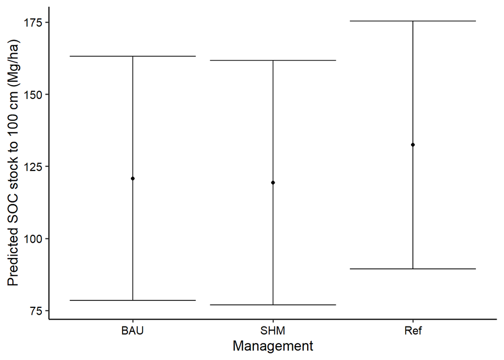

```r
# Plot predictions of 100cm SOC stocks under each treatment
pred_stock100 <- ggpredict(soc_stock100_mixed, terms = c("label"))
ggplot(pred_stock100, aes(x=x, y=predicted)) +
  geom_point() +
  geom_errorbar(aes(x=x, ymin=conf.low, ymax=conf.high)) +
  labs(x="Management", y="Predicted SOC stock to 100 cm (Mg/ha)") +
  theme_katy()
```

```r
# 100-cm SOC stocks look the same under all treatments

# Test significance of treatment by comparing full and reduced models, use likelihood ratio test
stock100_mixed_full <- lmer(soc_stock_100cm ~ label + (1|soil), data = soc_pedon_filt100, REML = FALSE)
stock100_mixed_reduced <- lmer(soc_stock_100cm ~ (1|soil), data = soc_pedon_filt100, REML = FALSE)
anova(stock100_mixed_full, stock100_mixed_reduced, text="Chisq")
```

```
## Data: soc_pedon_filt100
## Models:
## stock100_mixed_reduced: soc_stock_100cm ~ (1 | soil)
## stock100_mixed_full: soc_stock_100cm ~ label + (1 | soil)
##                        npar    AIC    BIC  logLik deviance  Chisq Df Pr(>Chisq)
## stock100_mixed_reduced    3 1745.7 1755.1 -869.84   1739.7
## stock100_mixed_full       5 1746.4 1762.1 -868.20   1736.4 3.2901  2      0.193
```

The results of the mixed model: Soil series explains most of the variability in SOC stocks. The full model with label as a fixed effect is not significantly different a reduced model with just soil as a random effect. Treatment is not a significant predictor of SOC stocks to 100 cm, only soil series is.